# Adaptive potential models

#### 8.4.1.1 **Interpretation of results**

Effect of GD is negative, meaning that species range shift less with high GD. Therefore, GD increases species’ ability to stay in place.

Interaction of GD:Lat is positive, suggesting that at higher latitudes a higher GD leads to faster shifts.

Interaction of velocity and GD (vel_abs_log_scale:GD_sqrt_scale) is positive, indicating that as climate velocities increase species with higher GD move faster to track climate change.

The positive effect of the interaction GD:velocity seems contradictory with the effect of GD alone. However, I believe they complement rather then contradict each other. The isolated negative effect of GD on range shifts indicates that overall GD increases species ability to stay in place. However, under scenarios of increasing climate change velocities, a higher GD will elevate species ability to track climate change.

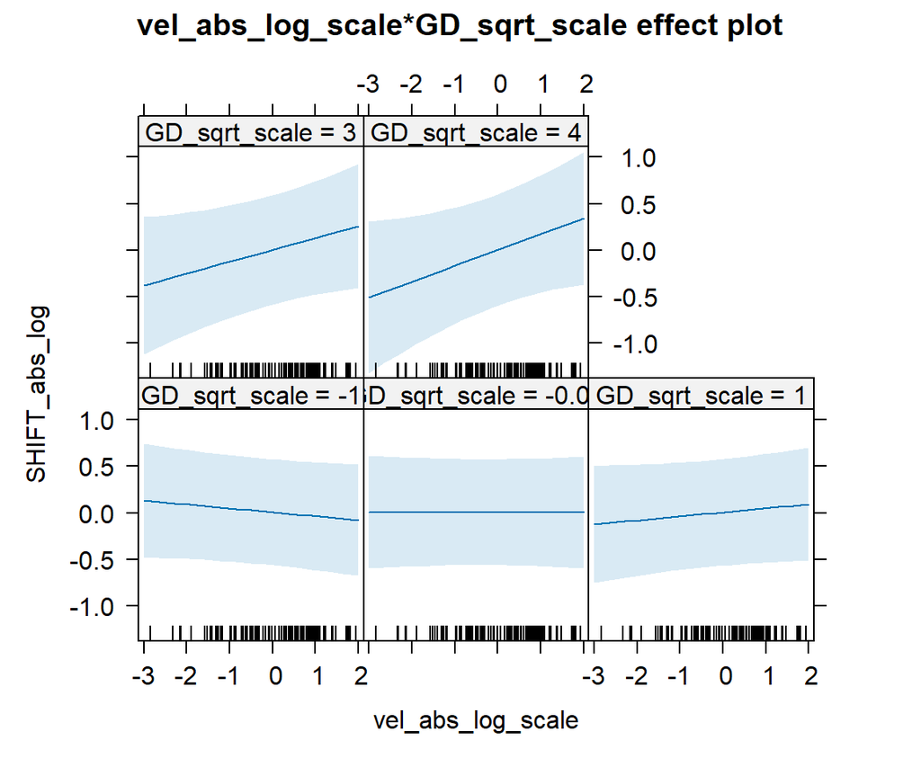

```r
plot(effects::effect("vel_abs_log_scale:GD_sqrt_scale", gau1))
```

### 8.4.2 Trying alternative model structures

```r
# try with separate Article_ID and Param
gau2 <- glmmTMB(
  SHIFT_abs_log ~
    vel_abs_log_scale * GD_sqrt_scale + # Ecology
    GD_sqrt_scale:Lat + # LGM effect on GD
    LogExtent + ContinuousGrain + Quality + PrAb + # Methods
    (1|Article_ID) + # Methods II
    (1|Param) + # Methods II
    (1|Class/Family), # Taxonomy
  data = mydatatogo)

summary(gau2)
```

```
##  Family: gaussian  ( identity )
## Formula:
## SHIFT_abs_log ~ vel_abs_log_scale * GD_sqrt_scale + GD_sqrt_scale:Lat +
##     LogExtent + ContinuousGrain + Quality + PrAb + (1 | Article_ID) +
##     (1 | Param) + (1 | Class/Family)
## Data: mydatatogo
##
##      AIC      BIC   logLik deviance df.resid
##  12620.1  12714.7  -6295.0  12590.1     4030
##
## Random effects:
##
## Conditional model:
##  Groups       Name        Variance Std.Dev.
##  Article_ID   (Intercept) 0.36312  0.6026
##  Param        (Intercept) 0.03368  0.1835
##  Family:Class (Intercept) 0.05903  0.2430
##  Class        (Intercept) 0.09369  0.3061
##  Residual                 1.23834  1.1128
## Number of obs: 4045, groups:
## Article_ID, 69; Param, 3; Family:Class, 272; Class, 7
##
## Dispersion estimate for gaussian family (sigma^2): 1.24
##
## Conditional model:
##                                  Estimate Std. Error z value Pr(>|z|)
## (Intercept)                     -3.697880   0.696259  -5.311 1.09e-07 ***
## vel_abs_log_scale               -0.026112   0.042198  -0.619   0.5360
## GD_sqrt_scale                   -0.232886   0.093682  -2.486   0.0129 *
## LogExtent                        0.563085   0.090591   6.216 5.11e-10 ***
## ContinuousGrain                  0.102001   0.087979   1.159   0.2463
## QualityRAW                       0.413235   0.222728   1.855   0.0635 .
## QualityRESURVEYED               -0.368878   0.256779  -1.437   0.1508
## PrAboccurrence                  -0.485957   0.213920  -2.272   0.0231 *
## vel_abs_log_scale:GD_sqrt_scale  0.039714   0.020120   1.974   0.0484 *
## GD_sqrt_scale:Lat                0.004890   0.001952   2.506   0.0122 *
## ---
## Signif. codes:  0 '***' 0.001 '**' 0.01 '*' 0.05 '.' 0.1 ' ' 1
```

```r
AIC(gau1, gau2)
```

```
##      df      AIC
## gau1 15 12578.25
## gau2 15 12620.09
```

```r
#      df      AIC
# gau1 15 12578.25
# gau2 15 12620.09

# gau1 is better
```

```r
# try random slope
gau3 <- glmmTMB(
  SHIFT_abs_log ~
    vel_abs_log_scale * GD_sqrt_scale + # Ecology
    GD_sqrt_scale:Lat + # LGM effect on GD
    LogExtent + ContinuousGrain + Quality + PrAb + # Methods
    (1|Param/Article_ID) + # Methods II
    (vel_abs_log_scale : GD_sqrt_scale|Class/Family), # Taxonomy
  data = mydatatogo)
# Warning: Model convergence problem; singular convergence (7). See vignette('troubleshooting'), help('diagnose')
diagnose(gau3)
```

```
## Unusually large coefficients (|x|>10):
##
## theta_vel_abs_log_scale:GD_sqrt_scale|Class.3
##                                     -244.7484
##
## Large negative coefficients in zi (log-odds of zero-inflation),
## dispersion, or random effects (log-standard deviations) suggest
## unnecessary components (converging to zero on the constrained scale);
## large negative and/or positive components in binomial or Poisson
## conditional parameters suggest (quasi-)complete separation. Large
## values of nbinom2 dispersion suggest that you should use a Poisson
## model instead.
##
##
## Unusually large Z-statistics (|x|>5):
##
##                                            LogExtent
##                                             5.968900
##                                        d~(Intercept)
##                                             8.050498
## theta_vel_abs_log_scale:GD_sqrt_scale|Family:Class.1
##                                           -10.466912
## theta_vel_abs_log_scale:GD_sqrt_scale|Family:Class.2
##                                            -6.638887
##
## Large Z-statistics (estimate/std err) suggest a *possible* failure of
## the Wald approximation - often also associated with parameters that are
## at or near the edge of their range (e.g. random-effects standard
## deviations approaching 0).  (Alternately, they may simply represent
## very well-estimated parameters; intercepts of non-centered models may
## fall in this category.) While the Wald p-values and standard errors
## listed in summary() may be unreliable, profile confidence intervals
## (see ?confint.glmmTMB) and likelihood ratio test p-values derived by
## comparing models (e.g. ?drop1) are probably still OK.  (Note that the
## LRT is conservative when the null value is on the boundary, e.g. a
## variance or zero-inflation value of 0 (Self and Liang 1987; Stram and
## Lee 1994; Goldman and Whelan 2000); in simple cases these p-values are
## approximately twice as large as they should be.)
```

```r
# random slope on vel_abs_log_scale:GD_sqrt_scale|Class is not helping
summary(gau3)
```

```
##  Family: gaussian  ( identity )
## Formula:
## SHIFT_abs_log ~ vel_abs_log_scale * GD_sqrt_scale + GD_sqrt_scale:Lat +
##     LogExtent + ContinuousGrain + Quality + PrAb + (1 | Param/Article_ID) +
##     (vel_abs_log_scale:GD_sqrt_scale | Class/Family)
## Data: mydatatogo
##
##      AIC      BIC   logLik deviance df.resid
##  12579.6  12699.4  -6270.8  12541.6     4026
##
## Random effects:
##
## Conditional model:
##  Groups           Name                            Variance Std.Dev. Corr
##  Article_ID:Param (Intercept)                     0.394648 0.62821
##  Param            (Intercept)                     0.100522 0.31705
##  Family:Class     (Intercept)                     0.054372 0.23318
##                   vel_abs_log_scale:GD_sqrt_scale 0.009946 0.09973  -0.20
##  Class            (Intercept)                     0.144421 0.38003
##                   vel_abs_log_scale:GD_sqrt_scale 0.001523 0.03902  -1.00
##  Residual                                         1.205598 1.09800
## Number of obs: 4045, groups:
## Article_ID:Param, 98; Param, 3; Family:Class, 272; Class, 7
##
## Dispersion estimate for gaussian family (sigma^2): 1.21
##
## Conditional model:
##                                  Estimate Std. Error z value Pr(>|z|)
## (Intercept)                     -3.104881   0.704469  -4.407 1.05e-05 ***
## vel_abs_log_scale                0.024739   0.042560   0.581 0.561061
## GD_sqrt_scale                   -0.196081   0.094367  -2.078 0.037722 *
## LogExtent                        0.519472   0.087030   5.969 2.39e-09 ***
## ContinuousGrain                  0.072263   0.079600   0.908 0.363971
## QualityRAW                       0.326460   0.208319   1.567 0.117086
## QualityRESURVEYED               -0.505335   0.220326  -2.294 0.021814 *
## PrAboccurrence                  -0.803103   0.214150  -3.750 0.000177 ***
## vel_abs_log_scale:GD_sqrt_scale  0.056452   0.029253   1.930 0.053635 .
## GD_sqrt_scale:Lat                0.004400   0.001954   2.251 0.024357 *
## ---
## Signif. codes:  0 '***' 0.001 '**' 0.01 '*' 0.05 '.' 0.1 ' ' 1
```

```r
gau3 <- glmmTMB(
  SHIFT_abs_log ~
    vel_abs_log_scale * GD_sqrt_scale + # Ecology
    GD_sqrt_scale:Lat + # LGM effect on GD
    LogExtent + ContinuousGrain + Quality + PrAb + # Methods
    (1|Param/Article_ID) + # Methods II
    (vel_abs_log_scale : GD_sqrt_scale|Group) + # Taxonomy
    (1|Class/Family),
  data = mydatatogo)
# Warning: Model convergence problem; non-positive-definite Hessian matrix. See vignette('troubleshooting')
diagnose(gau3)
```

```
## Unusually large coefficients (|x|>10):
##
## theta_vel_abs_log_scale:GD_sqrt_scale|Group.3
##                                     -229.8564
##
## Large negative coefficients in zi (log-odds of zero-inflation),
## dispersion, or random effects (log-standard deviations) suggest
## unnecessary components (converging to zero on the constrained scale);
## large negative and/or positive components in binomial or Poisson
## conditional parameters suggest (quasi-)complete separation. Large
## values of nbinom2 dispersion suggest that you should use a Poisson
## model instead.
##
##
## Unusually large Z-statistics (|x|>5):
##
##              LogExtent          d~(Intercept) theta_1|Family:Class.1
##               5.945218               8.463133             -10.556655
##
## Large Z-statistics (estimate/std err) suggest a *possible* failure of
## the Wald approximation - often also associated with parameters that are
## at or near the edge of their range (e.g. random-effects standard
## deviations approaching 0).  (Alternately, they may simply represent
## very well-estimated parameters; intercepts of non-centered models may
## fall in this category.) While the Wald p-values and standard errors
## listed in summary() may be unreliable, profile confidence intervals
## (see ?confint.glmmTMB) and likelihood ratio test p-values derived by
## comparing models (e.g. ?drop1) are probably still OK.  (Note that the
## LRT is conservative when the null value is on the boundary, e.g. a
## variance or zero-inflation value of 0 (Self and Liang 1987; Stram and
## Lee 1994; Goldman and Whelan 2000); in simple cases these p-values are
## approximately twice as large as they should be.)
```

```r
summary(gau3) # random slope on vel_abs_log_scale:GD_sqrt_scale|Group is not helping
```

```
##  Family: gaussian  ( identity )
## Formula:
## SHIFT_abs_log ~ vel_abs_log_scale * GD_sqrt_scale + GD_sqrt_scale:Lat +
##     LogExtent + ContinuousGrain + Quality + PrAb + (1 | Param/Article_ID) +
##     (vel_abs_log_scale:GD_sqrt_scale | Group) + (1 | Class/Family)
## Data: mydatatogo
##
##      AIC      BIC   logLik deviance df.resid
##  12577.4  12690.9  -6270.7  12541.4     4027
##
## Random effects:
##
## Conditional model:
##  Groups           Name                            Variance Std.Dev. Corr
##  Article_ID:Param (Intercept)                     0.383862 0.61957
##  Param            (Intercept)                     0.098220 0.31340
##  Group            (Intercept)                     0.177894 0.42178
##                   vel_abs_log_scale:GD_sqrt_scale 0.001274 0.03569  -1.00
##  Family:Class     (Intercept)                     0.053455 0.23120
##  Class            (Intercept)                     0.009168 0.09575
##  Residual                                         1.214555 1.10207
## Number of obs: 4045, groups:
## Article_ID:Param, 98; Param, 3; Group, 4; Family:Class, 272; Class, 7
##
## Dispersion estimate for gaussian family (sigma^2): 1.21
##
## Conditional model:
##                                  Estimate Std. Error z value Pr(>|z|)
## (Intercept)                     -2.935352   0.716480  -4.097 4.19e-05 ***
## vel_abs_log_scale                0.015373   0.042336   0.363 0.716514
## GD_sqrt_scale                   -0.197694   0.093416  -2.116 0.034321 *
## LogExtent                        0.515295   0.086674   5.945 2.76e-09 ***
## ContinuousGrain                  0.059492   0.078062   0.762 0.445989
## QualityRAW                       0.330193   0.206658   1.598 0.110093
## QualityRESURVEYED               -0.452472   0.214184  -2.113 0.034641 *
## PrAboccurrence                  -0.766033   0.213506  -3.588 0.000333 ***
## vel_abs_log_scale:GD_sqrt_scale  0.037036   0.027394   1.352 0.176386
## GD_sqrt_scale:Lat                0.004284   0.001940   2.208 0.027234 *
## ---
## Signif. codes:  0 '***' 0.001 '**' 0.01 '*' 0.05 '.' 0.1 ' ' 1
```

```r
gau3 <- glmmTMB(
  SHIFT_abs_log ~
    vel_abs_log_scale * GD_sqrt_scale + # Ecology
    GD_sqrt_scale:Lat + # LGM effect on GD
    LogExtent + ContinuousGrain + Quality + PrAb + # Methods
    (1|Param/Article_ID) + # Methods II
    (vel_abs_log_scale : GD_sqrt_scale|Group) + # Taxonomy
    (1|Order/Family),
  data = mydatatogo)
# Warning: Model convergence problem; non-positive-definite Hessian matrix. See vignette('troubleshooting')

summary(gau3) # random slope on vel_abs_log_scale:GD_sqrt_scale|Group is not helping
```

```
##  Family: gaussian  ( identity )
## Formula:
## SHIFT_abs_log ~ vel_abs_log_scale * GD_sqrt_scale + GD_sqrt_scale:Lat +
##     LogExtent + ContinuousGrain + Quality + PrAb + (1 | Param/Article_ID) +
##     (vel_abs_log_scale:GD_sqrt_scale | Group) + (1 | Order/Family)
## Data: mydatatogo
##
##      AIC      BIC   logLik deviance df.resid
##  12577.8  12691.3  -6270.9  12541.8     4027
##
## Random effects:
##
## Conditional model:
##  Groups           Name                            Variance  Std.Dev.  Corr
##  Article_ID:Param (Intercept)                     3.847e-01 6.202e-01
##  Param            (Intercept)                     9.848e-02 3.138e-01
##  Group            (Intercept)                     1.956e-01 4.423e-01
##                   vel_abs_log_scale:GD_sqrt_scale 1.346e-03 3.669e-02 -1.00
##  Family:Order     (Intercept)                     5.288e-02 2.300e-01
##  Order            (Intercept)                     4.630e-59 6.804e-30
##  Residual                                         1.215e+00 1.102e+00
## Number of obs: 4045, groups:
## Article_ID:Param, 98; Param, 3; Group, 4; Family:Order, 272; Order, 73
##
## Dispersion estimate for gaussian family (sigma^2): 1.22
##
## Conditional model:
##                                  Estimate Std. Error z value Pr(>|z|)
## (Intercept)                     -2.947329        NaN     NaN      NaN
## vel_abs_log_scale                0.016239        NaN     NaN      NaN
## GD_sqrt_scale                   -0.193046        NaN     NaN      NaN
## LogExtent                        0.516228        NaN     NaN      NaN
## ContinuousGrain                  0.059181        NaN     NaN      NaN
## QualityRAW                       0.329060        NaN     NaN      NaN
## QualityRESURVEYED               -0.453875        NaN     NaN      NaN
## PrAboccurrence                  -0.765084        NaN     NaN      NaN
## vel_abs_log_scale:GD_sqrt_scale  0.037439        NaN     NaN      NaN
## GD_sqrt_scale:Lat                0.004179        NaN     NaN      NaN
```

```r
gau3 <- glmmTMB(
  SHIFT_abs_log ~
    vel_abs_log_scale * GD_sqrt_scale + # Ecology
    GD_sqrt_scale:Lat + # LGM effect on GD
    LogExtent + ContinuousGrain + Quality + PrAb + # Methods
    (1|Param/Article_ID) + # Methods II
    (vel_abs_log_scale : GD_sqrt_scale|Class), # Taxonomy
  data = mydatatogo)
# Doesn't converges but fits...
# random slope on vel_abs_log_scale:GD_sqrt_scale|Class is not helping
# the interaction of vel_abs_log_scale:GD_sqrt_scale becomes is significant!
summary(gau3)
```

```
##  Family: gaussian  ( identity )
## Formula:
## SHIFT_abs_log ~ vel_abs_log_scale * GD_sqrt_scale + GD_sqrt_scale:Lat +
##     LogExtent + ContinuousGrain + Quality + PrAb + (1 | Param/Article_ID) +
##     (vel_abs_log_scale:GD_sqrt_scale | Class)
## Data: mydatatogo
##
##      AIC      BIC   logLik deviance df.resid
##  12629.4  12730.3  -6298.7  12597.4     4029
##
## Random effects:
##
## Conditional model:
##  Groups           Name                            Variance Std.Dev. Corr
##  Article_ID:Param (Intercept)                     0.409533 0.63995
##  Param            (Intercept)                     0.097040 0.31151
##  Class            (Intercept)                     0.181393 0.42590
##                   vel_abs_log_scale:GD_sqrt_scale 0.002006 0.04479  -1.00
##  Residual                                         1.257762 1.12150
## Number of obs: 4045, groups:  Article_ID:Param, 98; Param, 3; Class, 7
##
## Dispersion estimate for gaussian family (sigma^2): 1.26
##
## Conditional model:
##                                  Estimate Std. Error z value Pr(>|z|)
## (Intercept)                     -3.227234   0.714584  -4.516 6.29e-06 ***
## vel_abs_log_scale                0.016083   0.042651   0.377 0.706105
## GD_sqrt_scale                   -0.195985   0.091297  -2.147 0.031819 *
## LogExtent                        0.530311   0.088066   6.022 1.73e-09 ***
## ContinuousGrain                  0.075959   0.080542   0.943 0.345635
## QualityRAW                       0.302970   0.211232   1.434 0.151487
## QualityRESURVEYED               -0.525281   0.223552  -2.350 0.018788 *
## PrAboccurrence                  -0.797167   0.217748  -3.661 0.000251 ***
## vel_abs_log_scale:GD_sqrt_scale  0.056358   0.027740   2.032 0.042184 *
## GD_sqrt_scale:Lat                0.004319   0.001901   2.272 0.023083 *
## ---
## Signif. codes:  0 '***' 0.001 '**' 0.01 '*' 0.05 '.' 0.1 ' ' 1
```

```r
AIC(gau1,gau3)
```

```
##      df      AIC
## gau1 15 12578.25
## gau3 16 12629.40
```

```r
# gau1 is better
```

*The random slope:* (gau3) SHIFT_abs_log ~ vel_abs_log_scale * GD_sqrt_scale + GD_sqrt_scale:Lat +  
LogExtent + ContinuousGrain + Quality + PrAb + (1 | Param:Article_ID) +  
(vel_abs_log_scale:GD_sqrt_scale | Class)

```r
summary(gau1)
```

```
##  Family: gaussian  ( identity )
## Formula:
## SHIFT_abs_log ~ vel_abs_log_scale * GD_sqrt_scale + GD_sqrt_scale:Lat +
##     LogExtent + ContinuousGrain + Quality + PrAb + (1 | Param/Article_ID) +
##     (1 | Class/Family)
## Data: mydatatogo
##
##      AIC      BIC   logLik deviance df.resid
##  12578.2  12672.8  -6274.1  12548.2     4030
##
## Random effects:
##
## Conditional model:
##  Groups           Name        Variance Std.Dev.
##  Article_ID:Param (Intercept) 0.39187  0.6260
##  Param            (Intercept) 0.10195  0.3193
##  Family:Class     (Intercept) 0.05669  0.2381
##  Class            (Intercept) 0.13308  0.3648
##  Residual                     1.21463  1.1021
## Number of obs: 4045, groups:
## Article_ID:Param, 98; Param, 3; Family:Class, 272; Class, 7
##
## Dispersion estimate for gaussian family (sigma^2): 1.21
##
## Conditional model:
##                                   Estimate Std. Error z value Pr(>|z|)
## (Intercept)                     -3.0627577  0.6993438  -4.379 1.19e-05 ***
## vel_abs_log_scale                0.0004356  0.0409604   0.011   0.9915
## GD_sqrt_scale                   -0.2184016  0.0930881  -2.346   0.0190 *
## LogExtent                        0.5176844  0.0867637   5.967 2.42e-09 ***
## ContinuousGrain                  0.0734416  0.0795389   0.923   0.3558
## QualityRAW                       0.3424847  0.2075638   1.650   0.0989 .
## QualityRESURVEYED               -0.4991544  0.2218642  -2.250   0.0245 *
## PrAboccurrence                  -0.8359630  0.2144536  -3.898 9.69e-05 ***
## vel_abs_log_scale:GD_sqrt_scale  0.0424079  0.0199651   2.124   0.0337 *
## GD_sqrt_scale:Lat                0.0046186  0.0019388   2.382   0.0172 *
## ---
## Signif. codes:  0 '***' 0.001 '**' 0.01 '*' 0.05 '.' 0.1 ' ' 1
```

```r
summary(gau3)
```

```
##  Family: gaussian  ( identity )
## Formula:
## SHIFT_abs_log ~ vel_abs_log_scale * GD_sqrt_scale + GD_sqrt_scale:Lat +
##     LogExtent + ContinuousGrain + Quality + PrAb + (1 | Param/Article_ID) +
##     (vel_abs_log_scale:GD_sqrt_scale | Class)
## Data: mydatatogo
##
##      AIC      BIC   logLik deviance df.resid
##  12629.4  12730.3  -6298.7  12597.4     4029
##
## Random effects:
##
## Conditional model:
##  Groups           Name                            Variance Std.Dev. Corr
##  Article_ID:Param (Intercept)                     0.409533 0.63995
##  Param            (Intercept)                     0.097040 0.31151
##  Class            (Intercept)                     0.181393 0.42590
##                   vel_abs_log_scale:GD_sqrt_scale 0.002006 0.04479  -1.00
##  Residual                                         1.257762 1.12150
## Number of obs: 4045, groups:  Article_ID:Param, 98; Param, 3; Class, 7
##
## Dispersion estimate for gaussian family (sigma^2): 1.26
##
## Conditional model:
##                                  Estimate Std. Error z value Pr(>|z|)
## (Intercept)                     -3.227234   0.714584  -4.516 6.29e-06 ***
## vel_abs_log_scale                0.016083   0.042651   0.377 0.706105
## GD_sqrt_scale                   -0.195985   0.091297  -2.147 0.031819 *
## LogExtent                        0.530311   0.088066   6.022 1.73e-09 ***
## ContinuousGrain                  0.075959   0.080542   0.943 0.345635
## QualityRAW                       0.302970   0.211232   1.434 0.151487
## QualityRESURVEYED               -0.525281   0.223552  -2.350 0.018788 *
## PrAboccurrence                  -0.797167   0.217748  -3.661 0.000251 ***
## vel_abs_log_scale:GD_sqrt_scale  0.056358   0.027740   2.032 0.042184 *
## GD_sqrt_scale:Lat                0.004319   0.001901   2.272 0.023083 *
## ---
## Signif. codes:  0 '***' 0.001 '**' 0.01 '*' 0.05 '.' 0.1 ' ' 1
```

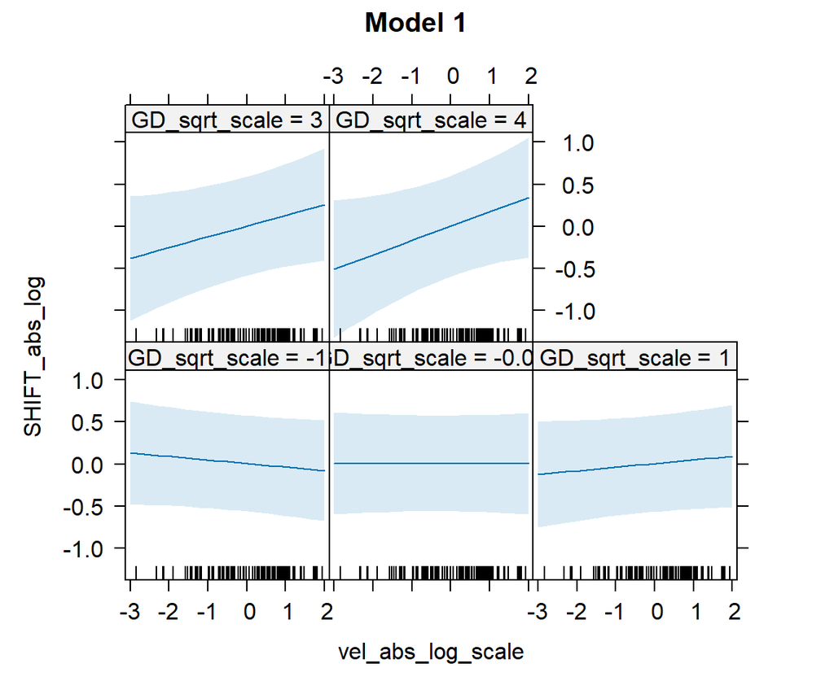

```r
plot(effects::effect("vel_abs_log_scale:GD_sqrt_scale", gau1), main = "Model 1")
```

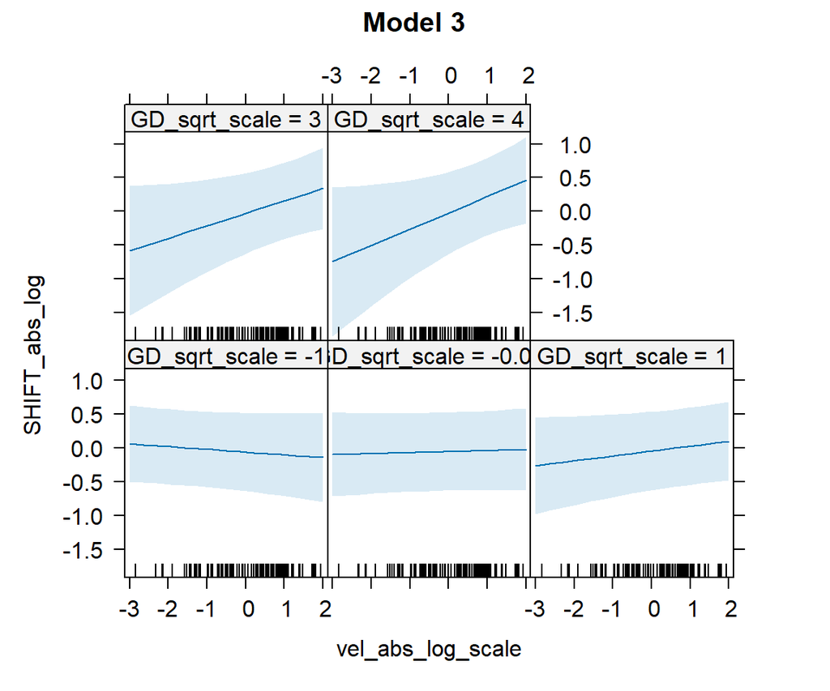

```r
plot(effects::effect("vel_abs_log_scale:GD_sqrt_scale", gau3), main = "Model 3")
```

## 8.5 GLM: Tajima’s vs velocity

We went further and use a different metric to investigate the potential modulating effect of genetic processes on range shifts. Tajima’s D is widely used to detect departure from neutrality that potentially result from population size change over time (Tajima, 1989). Tajima’s D is composed of two other metrics: the mean pairwise difference (π) and the number (S) of segregating sites, both representing an estimator of θ (theta). While the first metric measures the observed genetic variation in the sequences, the second metric quantifies the expected amount of genetic variation under the null model. Thus, under a scenario of constant population size, the observed amount of genetic variation (π) should be approximately equal to the expected genetic variation (S). For example, population expansions increase the number of rare variants (i.e., a polymorphic site present in only one—singletons—or in very few individuals) in the population, which leads to an increase in the expected value of theta. Conversely, rare polymorphisms lead to a lower value of π. The distortion between π and S, which represents a departure from mutation-drift equilibrium, is captured by Tajima’s D. Negative values are interpreted as an evidence of population expansion and positive values as population bottleneck. Note that while some authors have argued that significant results could result from positive or balancing selection, respectively, the demographic causes are the most common interpretation in phylogeographic studies and likely to be the most relevant for a global comparison (Fonseca et al. 2023).

Here, we keep the same model structure as before, but include Tajima’s D as an interaction term with climate velocity.

```r
gau11 <- glmmTMB(
  SHIFT_abs_log ~
    vel_abs_log_scale * TajimasD +# Ecology
    TajimasD:Lat + # LGM effect on GD
    LogExtent + ContinuousGrain + Quality + PrAb + # Methods
    (1|Param/Article_ID) + # Methods II
    (1|Class/Family), # Taxonomy
  data = mydatatogo)

summary(gau11)
```

```
##  Family: gaussian  ( identity )
## Formula:
## SHIFT_abs_log ~ vel_abs_log_scale * TajimasD + TajimasD:Lat +
##     LogExtent + ContinuousGrain + Quality + PrAb + (1 | Param/Article_ID) +
##     (1 | Class/Family)
## Data: mydatatogo
##
##      AIC      BIC   logLik deviance df.resid
##  12573.8  12668.4  -6271.9  12543.8     4030
##
## Random effects:
##
## Conditional model:
##  Groups           Name        Variance Std.Dev.
##  Article_ID:Param (Intercept) 0.40386  0.6355
##  Param            (Intercept) 0.09718  0.3117
##  Family:Class     (Intercept) 0.05186  0.2277
##  Class            (Intercept) 0.12768  0.3573
##  Residual                     1.21452  1.1021
## Number of obs: 4045, groups:
## Article_ID:Param, 98; Param, 3; Family:Class, 272; Class, 7
##
## Dispersion estimate for gaussian family (sigma^2): 1.21
##
## Conditional model:
##                              Estimate Std. Error z value Pr(>|z|)
## (Intercept)                -3.1593797  0.7049369  -4.482 7.40e-06 ***
## vel_abs_log_scale           0.2106428  0.0842695   2.500  0.01243 *
## TajimasD                   -0.0585638  0.0300454  -1.949  0.05127 .
## LogExtent                   0.5243938  0.0872389   6.011 1.84e-09 ***
## ContinuousGrain             0.0785997  0.0806415   0.975  0.32972
## QualityRAW                  0.3258501  0.2098357   1.553  0.12045
## QualityRESURVEYED          -0.5113307  0.2248073  -2.275  0.02293 *
## PrAboccurrence             -0.8259418  0.2158853  -3.826  0.00013 ***
## vel_abs_log_scale:TajimasD  0.0521793  0.0172810   3.019  0.00253 **
## TajimasD:Lat                0.0010344  0.0005082   2.035  0.04180 *
## ---
## Signif. codes:  0 '***' 0.001 '**' 0.01 '*' 0.05 '.' 0.1 ' ' 1
```

```r
gau13 <- glmmTMB(
  SHIFT_abs_log ~
    vel_abs_log_scale * TajimasD + # Ecology
    TajimasD:Lat + # LGM effect on GD
    LogExtent + ContinuousGrain + Quality + PrAb + # Methods
    (1|Param/Article_ID) + # Methods II
    (vel_abs_log_scale : TajimasD|Class), # Taxonomy
  data = mydatatogo)
# convergence issue
summary(gau13)
```

```
##  Family: gaussian  ( identity )
## Formula:
## SHIFT_abs_log ~ vel_abs_log_scale * TajimasD + TajimasD:Lat +
##     LogExtent + ContinuousGrain + Quality + PrAb + (1 | Param/Article_ID) +
##     (vel_abs_log_scale:TajimasD | Class)
## Data: mydatatogo
##
##      AIC      BIC   logLik deviance df.resid
##  12603.4  12704.2  -6285.7  12571.4     4029
##
## Random effects:
##
## Conditional model:
##  Groups           Name                       Variance Std.Dev. Corr
##  Article_ID:Param (Intercept)                0.470733 0.68610
##  Param            (Intercept)                0.097750 0.31265
##  Class            (Intercept)                0.146250 0.38243
##                   vel_abs_log_scale:TajimasD 0.001526 0.03907  -1.00
##  Residual                                    1.246338 1.11639
## Number of obs: 4045, groups:  Article_ID:Param, 98; Param, 3; Class, 7
##
## Dispersion estimate for gaussian family (sigma^2): 1.25
##
## Conditional model:
##                             Estimate Std. Error z value Pr(>|z|)
## (Intercept)                -3.247394        NaN     NaN      NaN
## vel_abs_log_scale           0.291308        NaN     NaN      NaN
## TajimasD                   -0.065040        NaN     NaN      NaN
## LogExtent                   0.546245        NaN     NaN      NaN
## ContinuousGrain             0.057863        NaN     NaN      NaN
## QualityRAW                  0.258880        NaN     NaN      NaN
## QualityRESURVEYED          -0.607066        NaN     NaN      NaN
## PrAboccurrence             -0.844048        NaN     NaN      NaN
## vel_abs_log_scale:TajimasD  0.066277        NaN     NaN      NaN
## TajimasD:Lat                0.001071        NaN     NaN      NaN
```

```r
gau13 <- glmmTMB(
  SHIFT_abs_log ~
    vel_abs_log_scale * TajimasD + # Ecology
    TajimasD:Lat + # LGM effect on GD
    LogExtent + ContinuousGrain + Quality + PrAb + # Methods
    (1|Param/Article_ID) + # Methods II
    (vel_abs_log_scale : TajimasD|Group), # Taxonomy
  data = mydatatogo)
# Works
# but not significant vel_abs_log_scale:TajimasD
summary(gau13)
```

```
##  Family: gaussian  ( identity )
## Formula:
## SHIFT_abs_log ~ vel_abs_log_scale * TajimasD + TajimasD:Lat +
##     LogExtent + ContinuousGrain + Quality + PrAb + (1 | Param/Article_ID) +
##     (vel_abs_log_scale:TajimasD | Group)
## Data: mydatatogo
##
##      AIC      BIC   logLik deviance df.resid
##  12599.1  12700.0  -6283.6  12567.1     4029
##
## Random effects:
##
## Conditional model:
##  Groups           Name                       Variance Std.Dev. Corr
##  Article_ID:Param (Intercept)                0.449777 0.67065
##  Param            (Intercept)                0.098327 0.31357
##  Group            (Intercept)                0.227750 0.47723
##                   vel_abs_log_scale:TajimasD 0.001543 0.03928  -0.89
##  Residual                                    1.246618 1.11652
## Number of obs: 4045, groups:  Article_ID:Param, 98; Param, 3; Group, 4
##
## Dispersion estimate for gaussian family (sigma^2): 1.25
##
## Conditional model:
##                              Estimate Std. Error z value Pr(>|z|)
## (Intercept)                -3.0421240  0.7432523  -4.093 4.26e-05 ***
## vel_abs_log_scale           0.2893424  0.0856785   3.377 0.000733 ***
## TajimasD                   -0.0614225  0.0298397  -2.058 0.039550 *
## LogExtent                   0.5312133  0.0885116   6.002 1.95e-09 ***
## ContinuousGrain             0.0392650  0.0828504   0.474 0.635552
## QualityRAW                  0.2956362  0.2192160   1.349 0.177463
## QualityRESURVEYED          -0.5190410  0.2292756  -2.264 0.023585 *
## PrAboccurrence             -0.8014269  0.2234954  -3.586 0.000336 ***
## vel_abs_log_scale:TajimasD  0.0491220  0.0265134   1.853 0.063922 .
## TajimasD:Lat                0.0009412  0.0004936   1.907 0.056549 .
## ---
## Signif. codes:  0 '***' 0.001 '**' 0.01 '*' 0.05 '.' 0.1 ' ' 1
```

```r
gau13 <- glmmTMB(
  SHIFT_abs_log ~
    vel_abs_log_scale * TajimasD + # Ecology
    TajimasD:Lat + # LGM effect on GD
    LogExtent + ContinuousGrain + Quality + PrAb + # Methods
    (1|Param/Article_ID) + # Methods II
    (vel_abs_log_scale : TajimasD|Class:Family), # Taxonomy
  data = mydatatogo)
# Works
summary(gau13)
```

```
##  Family: gaussian  ( identity )
## Formula:
## SHIFT_abs_log ~ vel_abs_log_scale * TajimasD + TajimasD:Lat +
##     LogExtent + ContinuousGrain + Quality + PrAb + (1 | Param/Article_ID) +
##     (vel_abs_log_scale:TajimasD | Class:Family)
## Data: mydatatogo
##
##      AIC      BIC   logLik deviance df.resid
##  12578.2  12679.1  -6273.1  12546.2     4029
##
## Random effects:
##
## Conditional model:
##  Groups           Name                       Variance  Std.Dev. Corr
##  Article_ID:Param (Intercept)                0.5168243 0.71890
##  Param            (Intercept)                0.1124204 0.33529
##  Class:Family     (Intercept)                0.0509369 0.22569
##                   vel_abs_log_scale:TajimasD 0.0006648 0.02578  -0.07
##  Residual                                    1.2051781 1.09781
## Number of obs: 4045, groups:  Article_ID:Param, 98; Param, 3; Class:Family, 272
##
## Dispersion estimate for gaussian family (sigma^2): 1.21
##
## Conditional model:
##                              Estimate Std. Error z value Pr(>|z|)
## (Intercept)                -3.2056722  0.6908383  -4.640 3.48e-06 ***
## vel_abs_log_scale           0.2250059  0.0861896   2.611  0.00904 **
## TajimasD                   -0.0572913  0.0300020  -1.910  0.05619 .
## LogExtent                   0.5608370  0.0863554   6.495 8.33e-11 ***
## ContinuousGrain             0.1310595  0.0833198   1.573  0.11573
## QualityRAW                  0.2896461  0.2217729   1.306  0.19154
## QualityRESURVEYED          -0.7345843  0.2263120  -3.246  0.00117 **
## PrAboccurrence             -0.8910868  0.2075108  -4.294 1.75e-05 ***
## vel_abs_log_scale:TajimasD  0.0516911  0.0178568   2.895  0.00379 **
## TajimasD:Lat                0.0009854  0.0005068   1.944  0.05184 .
## ---
## Signif. codes:  0 '***' 0.001 '**' 0.01 '*' 0.05 '.' 0.1 ' ' 1
```

```r
# Group:Family vel_abs_log_scale:TajimasD explains very little


AIC(gau11,gau13)
```

```
##       df      AIC
## gau11 15 12573.80
## gau13 16 12578.25
```

```r
# gau11 is better
```

###**Interpretation of results** Range shifts are positively associated with climate velocity, suggesting shift magnitudes increase with climate exposure. Range shifts are negatively correlated with Tajima’s D, suggesting species that show signature of population contraction shift less. Moreover, the interaction term indicates range shifts are positively associated with climate velocity when Tajima’s D is positive (evidence of population contraction). This indicates that under populations contraction, species tend to track climate change more closely (otherwise they go extinct). In contrast, when populations expand species are more likely to remain in place and don’t move to track climate change.

## 8.6 GAMM: GD vs velocity

```r
# first we contrast models with a thin plate regression spline (default smoother in GAM) with models with a tensor smooth product

# GD_gamm1 <- gamm(
#   SHIFT_abs_log ~
#     GD_sqrt_scale + vel_abs_log_scale + GD_sqrt_scale:Lat +
#     s(GD_sqrt_scale, vel_abs_log_scale) + # interaction between smoothed variables
#     LogExtent + ContinuousGrain + Quality + PrAb, # fixed effects of methods
#   random = list(
#     Param=~1, # random effect of Param
#     Article_ID=~1, # random effect of Study
#     Class=~1), # random effect of Class
#   data = mydatatogo)
# singularity issues

GD_gamm1 <- gamm(
  SHIFT_abs_log ~
    s(GD_sqrt_scale, vel_abs_log_scale) + # interaction between smoothed variables
    LogExtent + ContinuousGrain + Quality + PrAb, # fixed effects of methods
  random = list(
    Param=~1, # random effect of Param
    Article_ID=~1, # random effect of Study
    Class=~1), # random effect of Class
  data = mydatatogo)

summary(GD_gamm1$gam)
```

```
##
## Family: gaussian
## Link function: identity
##
## Formula:
## SHIFT_abs_log ~ s(GD_sqrt_scale, vel_abs_log_scale) + LogExtent +
##     ContinuousGrain + Quality + PrAb
##
## Parametric coefficients:
##                   Estimate Std. Error t value Pr(>|t|)
## (Intercept)       -3.08308    0.69848  -4.414 1.04e-05 ***
## LogExtent          0.55834    0.08766   6.369 2.11e-10 ***
## ContinuousGrain    0.14196    0.08579   1.655 0.098045 .
## QualityRAW         0.25321    0.22969   1.102 0.270350
## QualityRESURVEYED -0.79462    0.23431  -3.391 0.000702 ***
## PrAboccurrence    -0.93897    0.20952  -4.481 7.62e-06 ***
## ---
## Signif. codes:  0 '***' 0.001 '**' 0.01 '*' 0.05 '.' 0.1 ' ' 1
##
## Approximate significance of smooth terms:
##                                      edf Ref.df     F p-value
## s(GD_sqrt_scale,vel_abs_log_scale) 10.67  10.67 1.858  0.0465 *
## ---
## Signif. codes:  0 '***' 0.001 '**' 0.01 '*' 0.05 '.' 0.1 ' ' 1
##
## R-sq.(adj) =    0.2
##   Scale est. = 1.2522    n = 4045
```

```r
GD_gamm2 <- gamm(
  SHIFT_abs_log ~
    ti(GD_sqrt_scale, vel_abs_log_scale) + # interaction between smoothed variables (using a tensor smoother)
    LogExtent + ContinuousGrain + Quality + PrAb, # fixed effects of methods
  random = list(
    Param=~1, # random effect of Param
    Article_ID=~1, # random effect of Study
    Class=~1), # random effect of Class
  data = mydatatogo)

summary(GD_gamm2$gam)
```

```
##
## Family: gaussian
## Link function: identity
##
## Formula:
## SHIFT_abs_log ~ ti(GD_sqrt_scale, vel_abs_log_scale) + LogExtent +
##     ContinuousGrain + Quality + PrAb
##
## Parametric coefficients:
##                   Estimate Std. Error t value Pr(>|t|)
## (Intercept)       -3.20959    0.69183  -4.639 3.61e-06 ***
## LogExtent          0.57498    0.08713   6.599 4.68e-11 ***
## ContinuousGrain    0.12919    0.08488   1.522  0.12808
## QualityRAW         0.29209    0.22595   1.293  0.19619
## QualityRESURVEYED -0.75601    0.23109  -3.271  0.00108 **
## PrAboccurrence    -0.93030    0.20706  -4.493 7.22e-06 ***
## ---
## Signif. codes:  0 '***' 0.001 '**' 0.01 '*' 0.05 '.' 0.1 ' ' 1
##
## Approximate significance of smooth terms:
##                                      edf Ref.df     F p-value
## ti(GD_sqrt_scale,vel_abs_log_scale) 2.91   2.91 3.175  0.0381 *
## ---
## Signif. codes:  0 '***' 0.001 '**' 0.01 '*' 0.05 '.' 0.1 ' ' 1
##
## R-sq.(adj) =  0.213
##   Scale est. = 1.2579    n = 4045
```

```r
anova(GD_gamm1$lme, GD_gamm2$lme)
```

```
##              Model df      AIC      BIC    logLik
## GD_gamm1$lme     1 13 12632.23 12714.20 -6303.115
## GD_gamm2$lme     2 13 12635.29 12717.26 -6304.644
```

Models 1 and 2 are identical based on AIC. I will keep the tensor smoother from model2 as it leads to higher r-squared and <P-values for the interaction term…

In addition, I check if including the GD and velocity in the model helps…

```r
GD_gamm3 <- gamm(
  SHIFT_abs_log ~
    GD_sqrt_scale + vel_abs_log_scale + GD_sqrt_scale:Lat +
    ti(GD_sqrt_scale, vel_abs_log_scale) + # interaction between smoothed variables (using a tensor smoother)
    LogExtent + ContinuousGrain + Quality + PrAb, # fixed effects of methods
  random = list(
    Param=~1, # random effect of Param
    Article_ID=~1, # random effect of Study
    Class=~1), # random effect of Class
  data = mydatatogo)

summary(GD_gamm3$gam)
```

```
##
## Family: gaussian
## Link function: identity
##
## Formula:
## SHIFT_abs_log ~ GD_sqrt_scale + vel_abs_log_scale + GD_sqrt_scale:Lat +
##     ti(GD_sqrt_scale, vel_abs_log_scale) + LogExtent + ContinuousGrain +
##     Quality + PrAb
##
## Parametric coefficients:
##                    Estimate Std. Error t value Pr(>|t|)
## (Intercept)       -3.177706   0.691602  -4.595 4.47e-06 ***
## GD_sqrt_scale     -0.208211   0.090809  -2.293 0.021908 *
## vel_abs_log_scale  0.032573   0.043393   0.751 0.452903
## LogExtent          0.569557   0.087089   6.540 6.92e-11 ***
## ContinuousGrain    0.136820   0.084768   1.614 0.106593
## QualityRAW         0.280721   0.226161   1.241 0.214587
## QualityRESURVEYED -0.769279   0.230626  -3.336 0.000859 ***
## PrAboccurrence    -0.933321   0.206633  -4.517 6.46e-06 ***
## GD_sqrt_scale:Lat  0.004370   0.001898   2.302 0.021370 *
## ---
## Signif. codes:  0 '***' 0.001 '**' 0.01 '*' 0.05 '.' 0.1 ' ' 1
##
## Approximate significance of smooth terms:
##                                      edf Ref.df     F p-value
## ti(GD_sqrt_scale,vel_abs_log_scale) 2.15   2.15 4.549 0.00814 **
## ---
## Signif. codes:  0 '***' 0.001 '**' 0.01 '*' 0.05 '.' 0.1 ' ' 1
##
## R-sq.(adj) =  0.218
##   Scale est. = 1.2564    n = 4045
```

```r
anova(GD_gamm2$lme, GD_gamm3$lme)
```

```
##              Model df      AIC      BIC    logLik   Test L.Ratio p-value
## GD_gamm2$lme     1 13 12635.29 12717.26 -6304.644
## GD_gamm3$lme     2 16 12634.76 12735.64 -6301.379 1 vs 2 6.52952  0.0885
```

There is no difference between model 2 and 3. I will keep model 3 as it leads to higher r-squared and <P-values for the interaction term…

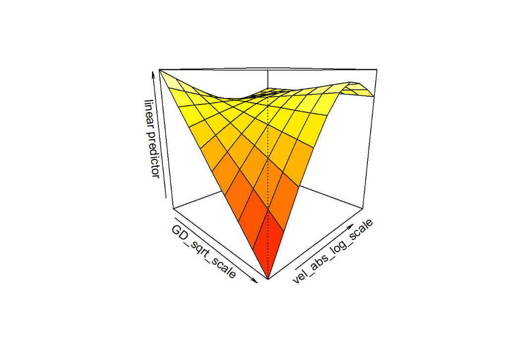

```r
vis.gam(GD_gamm3$gam,
        view = c("GD_sqrt_scale","vel_abs_log_scale"),
        n.grid = 10,
        theta = 45)
```

Test if including a random slope helps…

```r
GD_gamm4 <- gamm(
  SHIFT_abs_log ~
    GD_sqrt_scale + vel_abs_log_scale + GD_sqrt_scale:Lat +
    ti(GD_sqrt_scale, vel_abs_log_scale) + # interaction between smoothed variables (using a tensor smoother)
    LogExtent + ContinuousGrain + Quality + PrAb, # fixed effects of methods
  random = list(
    Param=~1, # random effect of Param
    Article_ID=~1, # random effect of Study
    Class=~GD_sqrt_scale), # random slope of GD on Class
  data = mydatatogo)

summary(GD_gamm4$gam)
```

```
##
## Family: gaussian
## Link function: identity
##
## Formula:
## SHIFT_abs_log ~ GD_sqrt_scale + vel_abs_log_scale + GD_sqrt_scale:Lat +
##     ti(GD_sqrt_scale, vel_abs_log_scale) + LogExtent + ContinuousGrain +
##     Quality + PrAb
##
## Parametric coefficients:
##                    Estimate Std. Error t value Pr(>|t|)
## (Intercept)       -3.177712   0.691598  -4.595 4.47e-06 ***
## GD_sqrt_scale     -0.208211   0.090809  -2.293 0.021908 *
## vel_abs_log_scale  0.032571   0.043393   0.751 0.452925
## LogExtent          0.569558   0.087089   6.540 6.92e-11 ***
## ContinuousGrain    0.136820   0.084768   1.614 0.106592
## QualityRAW         0.280722   0.226161   1.241 0.214585
## QualityRESURVEYED -0.769278   0.230626  -3.336 0.000859 ***
## PrAboccurrence    -0.933315   0.206632  -4.517 6.46e-06 ***
## GD_sqrt_scale:Lat  0.004370   0.001898   2.302 0.021371 *
## ---
## Signif. codes:  0 '***' 0.001 '**' 0.01 '*' 0.05 '.' 0.1 ' ' 1
##
## Approximate significance of smooth terms:
##                                      edf Ref.df     F p-value
## ti(GD_sqrt_scale,vel_abs_log_scale) 2.15   2.15 4.549 0.00814 **
## ---
## Signif. codes:  0 '***' 0.001 '**' 0.01 '*' 0.05 '.' 0.1 ' ' 1
##
## R-sq.(adj) =  0.218
##   Scale est. = 1.2564    n = 4045
```

```r
anova(GD_gamm3$lme, GD_gamm4$lme)
```

```
##              Model df      AIC      BIC    logLik   Test      L.Ratio p-value
## GD_gamm3$lme     1 16 12634.76 12735.64 -6301.379
## GD_gamm4$lme     2 18 12638.76 12752.25 -6301.379 1 vs 2 6.900809e-07       1
```

No!

## 8.7 GAMM: Tajima’s vs velocity

```r
# Taj_gamm1 <- gamm(
#   SHIFT_abs_log ~
#     TajimasD + vel_abs_log_scale + TajimasD:Lat +
#     s(TajimasD, vel_abs_log_scale) + # interaction between smoothed variables (using a tensor smoother)
#     LogExtent + ContinuousGrain + Quality + PrAb, # fixed effects of methods
#   random = list(
#     Param=~1, # random effect of Param
#     Article_ID=~1,
#     Class=~1), # random effect of Study
#   data = mydatatogo)
# singularity issue

Taj_gamm2 <- gamm(
  SHIFT_abs_log ~
    TajimasD + vel_abs_log_scale + TajimasD:Lat +
    ti(TajimasD, vel_abs_log_scale) + # interaction between smoothed variables (using a tensor smoother)
    LogExtent + ContinuousGrain + Quality + PrAb, # fixed effects of methods
  random = list(
    Param=~1, # random effect of Param
    Article_ID=~1,
    Class=~1), # random effect of Study
  data = mydatatogo)

summary(Taj_gamm2$gam)
```

```
##
## Family: gaussian
## Link function: identity
##
## Formula:
## SHIFT_abs_log ~ TajimasD + vel_abs_log_scale + TajimasD:Lat +
##     ti(TajimasD, vel_abs_log_scale) + LogExtent + ContinuousGrain +
##     Quality + PrAb
##
## Parametric coefficients:
##                     Estimate Std. Error t value Pr(>|t|)
## (Intercept)       -3.3114650  0.6959468  -4.758 2.02e-06 ***
## TajimasD          -0.0634484  0.0293188  -2.164 0.030516 *
## vel_abs_log_scale  0.0237107  0.0423270   0.560 0.575387
## LogExtent          0.5757799  0.0872726   6.597 4.72e-11 ***
## ContinuousGrain    0.1415567  0.0855532   1.655 0.098083 .
## QualityRAW         0.2625076  0.2279044   1.152 0.249458
## QualityRESURVEYED -0.7758423  0.2323486  -3.339 0.000848 ***
## PrAboccurrence    -0.9153470  0.2081953  -4.397 1.13e-05 ***
## TajimasD:Lat       0.0009801  0.0004934   1.986 0.047047 *
## ---
## Signif. codes:  0 '***' 0.001 '**' 0.01 '*' 0.05 '.' 0.1 ' ' 1
##
## Approximate significance of smooth terms:
##                                 edf Ref.df     F  p-value
## ti(TajimasD,vel_abs_log_scale) 1.85   1.85 7.081 0.000801 ***
## ---
## Signif. codes:  0 '***' 0.001 '**' 0.01 '*' 0.05 '.' 0.1 ' ' 1
##
## R-sq.(adj) =  0.208
##   Scale est. = 1.2539    n = 4045
```

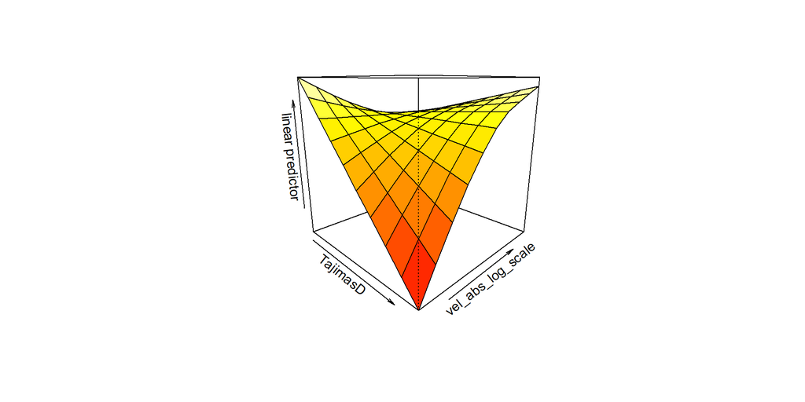

```r
vis.gam(Taj_gamm2$gam,
        view = c("TajimasD","vel_abs_log_scale"),
        n.grid = 10,
        theta = 45)
```

# 9 Elevation

```r
mydatatogo <- mydataset  %>%
  dplyr::filter(Type == "ELE") %>%
  mutate(
    vel_raw = velocity,
    vel = scale(vel_raw),
    vel_abs = abs(vel_raw),
    vel_abs_scale = scale(vel_abs),
    vel_abs_log = log(vel_abs),
    vel_abs_log_scale = scale(vel_abs_log),
    vel_abs_sqrt = sqrt(vel_abs),
    vel_abs_sqrt_scale = scale(vel_abs_sqrt),

    SHIFT_raw = SHIFT,
    SHIFT = scale(SHIFT_raw),
    SHIFT_abs = abs(SHIFT_raw),
    SHIFT_abs_log = log(SHIFT_abs),
    SHIFT_abs_log_scale = scale(SHIFT_abs_log),

    SHIFT_cor_raw = SHIFT_cor,
    SHIFT_cor = scale(SHIFT_cor_raw),
    SHIFT_cor_abs = abs(SHIFT_cor_raw),
    SHIFT_cor_abs_log = log(SHIFT_cor_abs),
    SHIFT_cor_abs_log_scale = scale(SHIFT_abs_log),

    ID.area = scale(ID.area),
    DUR = scale(DUR),
    LogExtent = log(Extent),
    Lat = abs(Latitude),

    START = scale(START),
    Param = factor(Param),
    Group = factor(Group),
    spp = factor(spp),

    GD = Nucleotide_diversity,
    GD_sqrt = sqrt(GD),
    GD_scale = scale(Nucleotide_diversity),
    GD_sqrt_scale = scale(sqrt(GD))) %>%

  dplyr::select(
    GD, GD_sqrt, GD_scale, GD_sqrt_scale, Lat, TajimasD, overlap_SA, R2,
    SHIFT, SHIFT_abs, SHIFT_abs_log, SHIFT_raw, SHIFT_abs_log_scale,
    SHIFT_cor, SHIFT_cor_abs, SHIFT_cor_abs_log, SHIFT_cor_raw, SHIFT_abs_log_scale,
    vel, vel_abs, vel_abs_scale, vel_abs_log, vel_raw, vel_abs_log_scale, vel_abs_sqrt, vel_abs_sqrt_scale,
    # min_dist, dist_weight,
    START, DUR, ID.area, Nperiodes, LogNtempUnits, NtempUnits, Extent, LogExtent, ContinuousGrain, Quality, PrAb, ExtentF, AreaF,
    Param, Group, spp, Class, Order, Family, Genus,
    ECO, Uncertainty_Parameter, Uncertainty_Distribution, Grain_size, Data, Sampling, Article_ID,
    # Marker,
    shift_vel_sign)

mydatatogo[,1:33] <- lapply(mydatatogo[,1:33], as.numeric)

mydatatogo <- data.frame(na.omit(mydatatogo))

# N dataset
nrow(mydatatogo)
```

```
## [1] 1641
```

```r
nrow(mydatatogo %>% dplyr::filter(GD > 0))
```

```
## [1] 1339
```

```r
# N species
length(unique(mydatatogo$spp))
```

```
## [1] 904
```

```r
# 1725

table(mydatatogo$Group)
```

```
##
##   Bird Insect  Plant
##    604    430    607
```

```r
# Bird   Fish Insect  Plant
# 1273    228   1735    812
mydatatogo$Param <- relevel(mydatatogo$Param, ref = "O")

table(mydatatogo$Param)
```

```
##
##   O  LE  TE
## 804 715 122
```

```r
table(mydatatogo$ContinuousGrain)
```

```
##
##    1    2    3
## 1134  467   40
```

```r
table(mydatatogo$Quality)
```

```
##
##   BALANCED        RAW RESURVEYED
##        634        674        333
```

```r
table(mydatatogo$PrAb)
```

```
##
##  abundance occurrence
##        438       1203
```

```r
table(mydatatogo$ExtentF)
```

```
##
## (1.75e+03,4.09e+03] (4.09e+03,8.75e+03]      (880,1.75e+03]          [33.8,880]
##                 592                 465                 252                 332
```

```r
table(mydatatogo$Order)
```

```
##
## Accipitriformes     Alismatales    Anseriformes         Apiales     Apodiformes
##               2               4               5              12               1
##     Asparagales       Asterales     Brassicales  Caryophyllales Ceratophyllales
##               8              41              14              58               1
## Charadriiformes      Coleoptera   Columbiformes        Cornales    Cuculiformes
##               7             210              10               1               7
##      Dipsacales         Diptera     Equisetales        Ericales         Fabales
##              22              20               3              21              22
##         Fagales   Falconiformes     Galliformes     Gentianales      Geraniales
##              12               4               4              11               7
##      Gruiformes     Hymenoptera        Lamiales     Lepidoptera        Liliales
##               2             120              59              72               6
##    Lycopodiales    Malpighiales        Malvales        Myrtales      Orthoptera
##               1              31               2              19               4
##      Oxalidales   Passeriformes  Pelecaniformes      Piciformes         Pinales
##               3             516               5              33              10
##      Plecoptera          Poales    Polypodiales   Polytrichales    Ranunculales
##               4             145               6               1              19
##         Rosales      Sapindales    Saxifragales       Solanales    Strigiformes
##              52               2               9               5               7
##      Suliformes
##               1
```

## 9.1 GLM: GD vs velocity

### 9.1.1 Gaussian vs Gamma model

```r
gau1 <- glmmTMB(
  SHIFT_abs_log ~
    vel_abs_log_scale * GD_sqrt_scale + # Ecology
    GD_sqrt_scale:Lat + # LGM effect on GD
    LogExtent + ContinuousGrain + Quality + PrAb + # Methods
    (1|Param/Article_ID) + # Methods II
    (1|Class/Family), # Taxonomy
  data = mydatatogo)
# Works!
summary(gau1)
```

```
##  Family: gaussian  ( identity )
## Formula:
## SHIFT_abs_log ~ vel_abs_log_scale * GD_sqrt_scale + GD_sqrt_scale:Lat +
##     LogExtent + ContinuousGrain + Quality + PrAb + (1 | Param/Article_ID) +
##     (1 | Class/Family)
## Data: mydatatogo
##
##      AIC      BIC   logLik deviance df.resid
##       NA       NA       NA       NA     1626
##
## Random effects:
##
## Conditional model:
##  Groups           Name        Variance  Std.Dev.
##  Article_ID:Param (Intercept) 3.458e-01 0.588029
##  Param            (Intercept) 3.973e-05 0.006304
##  Family:Class     (Intercept) 8.920e-06 0.002987
##  Class            (Intercept) 2.504e-01 0.500442
##  Residual                     1.242e+00 1.114403
## Number of obs: 1641, groups:
## Article_ID:Param, 91; Param, 3; Family:Class, 173; Class, 8
##
## Dispersion estimate for gaussian family (sigma^2): 1.24
##
## Conditional model:
##                                  Estimate Std. Error z value Pr(>|z|)
## (Intercept)                      0.662554   1.192403   0.556    0.578
## vel_abs_log_scale               -0.001274   0.054495  -0.023    0.981
## GD_sqrt_scale                   -0.018457   0.108966  -0.169    0.865
## LogExtent                       -0.011949   0.147861  -0.081    0.936
## ContinuousGrain                  0.063971   0.161317   0.397    0.692
## QualityRAW                       0.049842   0.231324   0.216    0.829
## QualityRESURVEYED               -0.116108   0.193037  -0.602    0.548
## PrAboccurrence                  -0.267944   0.189907  -1.411    0.158
## vel_abs_log_scale:GD_sqrt_scale  0.044953   0.032462   1.385    0.166
## GD_sqrt_scale:Lat               -0.001249   0.002334  -0.535    0.593
```

```r
gam1 <- glmmTMB(
  SHIFT_abs ~
    vel_abs_scale * GD_sqrt_scale + # Ecology
    GD_sqrt_scale:Lat + # LGM effect on GD
    LogExtent + ContinuousGrain + Quality + PrAb + # Methods
    (1|Param/Article_ID) + # Methods II
    (1|Class/Family), # Taxonomy
  family = Gamma(link = "log"),
  data = mydatatogo)
# Works!
summary(gam1)
```

```
##  Family: Gamma  ( log )
## Formula:
## SHIFT_abs ~ vel_abs_scale * GD_sqrt_scale + GD_sqrt_scale:Lat +
##     LogExtent + ContinuousGrain + Quality + PrAb + (1 | Param/Article_ID) +
##     (1 | Class/Family)
## Data: mydatatogo
##
##      AIC      BIC   logLik deviance df.resid
##   7284.9   7365.9  -3627.4   7254.9     1626
##
## Random effects:
##
## Conditional model:
##  Groups           Name        Variance Std.Dev.
##  Article_ID:Param (Intercept) 0.342445 0.58519
##  Param            (Intercept) 0.005951 0.07714
##  Family:Class     (Intercept) 0.014782 0.12158
##  Class            (Intercept) 0.149181 0.38624
## Number of obs: 1641, groups:
## Article_ID:Param, 91; Param, 3; Family:Class, 173; Class, 8
##
## Dispersion estimate for Gamma family (sigma^2): 0.833
##
## Conditional model:
##                              Estimate Std. Error z value Pr(>|z|)
## (Intercept)                  0.937250   1.132063   0.828    0.408
## vel_abs_scale               -0.007701   0.072681  -0.106    0.916
## GD_sqrt_scale                0.050857   0.092795   0.548    0.584
## LogExtent                    0.055251   0.140743   0.393    0.695
## ContinuousGrain             -0.090882   0.153550  -0.592    0.554
## QualityRAW                  -0.026807   0.223386  -0.120    0.904
## QualityRESURVEYED           -0.187311   0.185354  -1.011    0.312
## PrAboccurrence              -0.231448   0.186536  -1.241    0.215
## vel_abs_scale:GD_sqrt_scale  0.038006   0.027885   1.363    0.173
## GD_sqrt_scale:Lat           -0.002348   0.001988  -1.181    0.238
```

```r
anova(gau1,gam1)
```

```
## Data: mydatatogo
## Models:
## gau1: SHIFT_abs_log ~ vel_abs_log_scale * GD_sqrt_scale + GD_sqrt_scale:Lat + , zi=~0, disp=~1
## gau1:     LogExtent + ContinuousGrain + Quality + PrAb + (1 | Param/Article_ID) + , zi=~0, disp=~1
## gau1:     (1 | Class/Family), zi=~0, disp=~1
## gam1: SHIFT_abs ~ vel_abs_scale * GD_sqrt_scale + GD_sqrt_scale:Lat + , zi=~0, disp=~1
## gam1:     LogExtent + ContinuousGrain + Quality + PrAb + (1 | Param/Article_ID) + , zi=~0, disp=~1
## gam1:     (1 | Class/Family), zi=~0, disp=~1
##      Df    AIC    BIC  logLik deviance Chisq Chi Df Pr(>Chisq)
## gau1 15
## gam1 15 7284.9 7365.9 -3627.4   7254.9            0
```

No significant effects

## 9.2 GLM: Tajima’s vs velocity

```r
gau11 <- glmmTMB(
  SHIFT_abs_log ~
    vel_abs_log_scale * TajimasD +# Ecology
    TajimasD:Lat + # LGM effect on GD
    LogExtent + ContinuousGrain + Quality + PrAb + # Methods
    (1|Param/Article_ID) + # Methods II
    (1|Class/Family), # Taxonomy
  data = mydatatogo)

summary(gau11)
```

```
##  Family: gaussian  ( identity )
## Formula:
## SHIFT_abs_log ~ vel_abs_log_scale * TajimasD + TajimasD:Lat +
##     LogExtent + ContinuousGrain + Quality + PrAb + (1 | Param/Article_ID) +
##     (1 | Class/Family)
## Data: mydatatogo
##
##      AIC      BIC   logLik deviance df.resid
##   5163.7   5244.8  -2566.9   5133.7     1626
##
## Random effects:
##
## Conditional model:
##  Groups           Name        Variance  Std.Dev.
##  Article_ID:Param (Intercept) 3.349e-01 0.5786685
##  Param            (Intercept) 1.880e-08 0.0001371
##  Family:Class     (Intercept) 1.444e-02 0.1201595
##  Class            (Intercept) 2.038e-01 0.4514665
##  Residual                     1.235e+00 1.1111416
## Number of obs: 1641, groups:
## Article_ID:Param, 91; Param, 3; Family:Class, 173; Class, 8
##
## Dispersion estimate for gaussian family (sigma^2): 1.23
##
## Conditional model:
##                              Estimate Std. Error z value Pr(>|z|)
## (Intercept)                 0.5620963  1.1880819   0.473    0.636
## vel_abs_log_scale           0.1204892  0.1376379   0.875    0.381
## TajimasD                   -0.0562573  0.0381019  -1.476    0.140
## LogExtent                  -0.0023530  0.1470813  -0.016    0.987
## ContinuousGrain             0.0588431  0.1600148   0.368    0.713
## QualityRAW                  0.0905302  0.2307213   0.392    0.695
## QualityRESURVEYED          -0.1184648  0.1899591  -0.624    0.533
## PrAboccurrence             -0.2861880  0.1894660  -1.510    0.131
## vel_abs_log_scale:TajimasD  0.0288171  0.0281452   1.024    0.306
## TajimasD:Lat                0.0006377  0.0006771   0.942    0.346
```

No significant effects

## 9.3 GAMM: GD vs velocity

```r
GD_gamm3 <- gamm(
  SHIFT_abs_log ~
    GD_sqrt_scale + vel_abs_log_scale + GD_sqrt_scale:Lat +
    ti(GD_sqrt_scale, vel_abs_log_scale) + # interaction between smoothed variables (using a tensor smoother)
    LogExtent + ContinuousGrain + Quality + PrAb, # fixed effects of methods
  random = list(
    Param=~1, # random effect of Param
    Article_ID=~1, # random effect of Study
    Class=~1), # random effect of Class
  data = mydatatogo)

summary(GD_gamm3$gam)
```

```
##
## Family: gaussian
## Link function: identity
##
## Formula:
## SHIFT_abs_log ~ GD_sqrt_scale + vel_abs_log_scale + GD_sqrt_scale:Lat +
##     ti(GD_sqrt_scale, vel_abs_log_scale) + LogExtent + ContinuousGrain +
##     Quality + PrAb
##
## Parametric coefficients:
##                     Estimate Std. Error t value Pr(>|t|)
## (Intercept)        1.1119346  1.2415190   0.896  0.37059
## GD_sqrt_scale     -0.0072260  0.1104520  -0.065  0.94785
## vel_abs_log_scale  0.0317270  0.0563434   0.563  0.57344
## LogExtent          0.0119473  0.1576382   0.076  0.93960
## ContinuousGrain   -0.0923020  0.1678059  -0.550  0.58236
## QualityRAW         0.2069518  0.2470239   0.838  0.40228
## QualityRESURVEYED -0.0994879  0.2082208  -0.478  0.63286
## PrAboccurrence    -0.5654994  0.2001252  -2.826  0.00477 **
## GD_sqrt_scale:Lat -0.0009608  0.0023744  -0.405  0.68577
## ---
## Signif. codes:  0 '***' 0.001 '**' 0.01 '*' 0.05 '.' 0.1 ' ' 1
##
## Approximate significance of smooth terms:
##                                     edf Ref.df    F p-value
## ti(GD_sqrt_scale,vel_abs_log_scale)   1      1 1.93   0.165
##
## R-sq.(adj) =  0.00891
##   Scale est. = 1.244     n = 1641
```

## 9.4 GAMM: Tajima’s vs velocity

```r
Taj_gamm2 <- gamm(
  SHIFT_abs_log ~
    TajimasD + vel_abs_log_scale + TajimasD:Lat +
    ti(TajimasD, vel_abs_log_scale) + # interaction between smoothed variables (using a tensor smoother)
    LogExtent + ContinuousGrain + Quality + PrAb, # fixed effects of methods
  random = list(
    Param=~1, # random effect of Param
    Article_ID=~1,
    Class=~1), # random effect of Study
  data = mydatatogo)

summary(Taj_gamm2$gam)
```

```
##
## Family: gaussian
## Link function: identity
##
## Formula:
## SHIFT_abs_log ~ TajimasD + vel_abs_log_scale + TajimasD:Lat +
##     ti(TajimasD, vel_abs_log_scale) + LogExtent + ContinuousGrain +
##     Quality + PrAb
##
## Parametric coefficients:
##                     Estimate Std. Error t value Pr(>|t|)
## (Intercept)        0.9344223  1.2190360   0.767  0.44347
## TajimasD          -0.0494830  0.0377764  -1.310  0.19042
## vel_abs_log_scale  0.0370633  0.0570279   0.650  0.51584
## LogExtent          0.0273208  0.1542970   0.177  0.85948
## ContinuousGrain   -0.1077362  0.1641042  -0.657  0.51159
## QualityRAW         0.2484384  0.2419170   1.027  0.30459
## QualityRESURVEYED -0.0848007  0.2021099  -0.420  0.67485
## PrAboccurrence    -0.5475078  0.1957810  -2.797  0.00523 **
## TajimasD:Lat       0.0007728  0.0006639   1.164  0.24456
## ---
## Signif. codes:  0 '***' 0.001 '**' 0.01 '*' 0.05 '.' 0.1 ' ' 1
##
## Approximate significance of smooth terms:
##                                edf Ref.df     F p-value
## ti(TajimasD,vel_abs_log_scale)   1      1 1.453   0.228
##
## R-sq.(adj) =  0.0142
##   Scale est. = 1.2477    n = 1641
```